# Studying eviction-related variables and their relevance with COVID19 statistics

Olivia Jin, Jennifer Ko, Bea Lee, Chica Morrow

5/17/2020

# Introduction

Our group aims to look at US county-level data on eviction and demographics (e.g. eviction filings, poverty rate, and racial distributions), as well as their relevance with Covid-19 statistics like death and case rates. Using supervised and unsupervised learning, we explore the data that we obtained from USAFacts (https://usafacts.org/visualizations/coronavirus-covid-19-spread-map), Eviction Lab (https://evictionlab.org/), and US Census as of 4/30/2020 (https://www.census.gov/popclock/).

Given the wide range of learning techniques we explore in our project, each model address a different question.

# Table of Contents

Supervised Learning: - 1. LM (simple, long) - 2. knn - 3. Single Decision Trees, Bagging, Boosting and Random Forests - 4. LDA

Unsupervised Learning: - 1. PCA - 2. Hierarchical - 3. K-Means

Overall Analysis - Supervised vs Unsupervised - Supervised - Unsupervised

# [SUPERVISED LEARNING]

### Load Data

Loading appended data with COVID-19 and eviction data.

```r
covid.eviction <- read_csv("covid_eviction2.csv")
```

# 1. LM Models

# Simple LM

Question: Do eviction filing rates have an effect on COVID case rates at the county level?

A simple lm model uses only our independent variable of interest, eviction filing rates, on the right hand side.

```r
lm1 <- lm(county_covid_cases_rate ~ `eviction-filing-rate`,
          data = covid.eviction)
summary(lm1)
```

```
##
## Call:
## lm(formula = county_covid_cases_rate ~ `eviction-filing-rate`,
##     data = covid.eviction)
##
## Residuals:
##       Min        1Q    Median        3Q       Max
## -0.004502 -0.001107 -0.000784 -0.000126  0.061371
##
## Coefficients:
##                         Estimate Std. Error t value Pr(>|t|)
## (Intercept)            1.121e-03  7.062e-05  15.875  < 2e-16 ***
## `eviction-filing-rate` 9.185e-05  1.213e-05   7.573 4.95e-14 ***
## ---
## Signif. codes:  0 '***' 0.001 '**' 0.01 '*' 0.05 '.' 0.1 ' ' 1
##
## Residual standard error: 0.003119 on 2707 degrees of freedom
##   (432 observations deleted due to missingness)
## Multiple R-squared:  0.02075,    Adjusted R-squared:  0.02039
## F-statistic: 57.36 on 1 and 2707 DF,  p-value: 4.955e-14
```

The lm output gives us the R-squared and adjusted R-squared values which reperesent how well our model explains variations in our output/prediction.

## Adjusted R-squared:

The adjusted R-squared value here is low, meaning while the eviction filing rate is significant, its variations account for only 2% of the variation in COVID cases. To better optimize our lm model, we can consider how other variables may impact our coefficient on eviction or if they better explain COVID cases than eviction.

## F-statistic:

The F-test, which tells us whether our R-squared value is significantly different from 0, is significant, which leads us to conclude that our model overall is significant.

## Magnitude of Coefficients

Another way to assess the efficacy of our linear model is by looking at the magnitude of our coefficients. While significant at below the 0.1% level, it’s difficult to know what the coefficient of 9.185e-05 actually means.

A graph and summary statistics can help us visualize what this slope actually means:

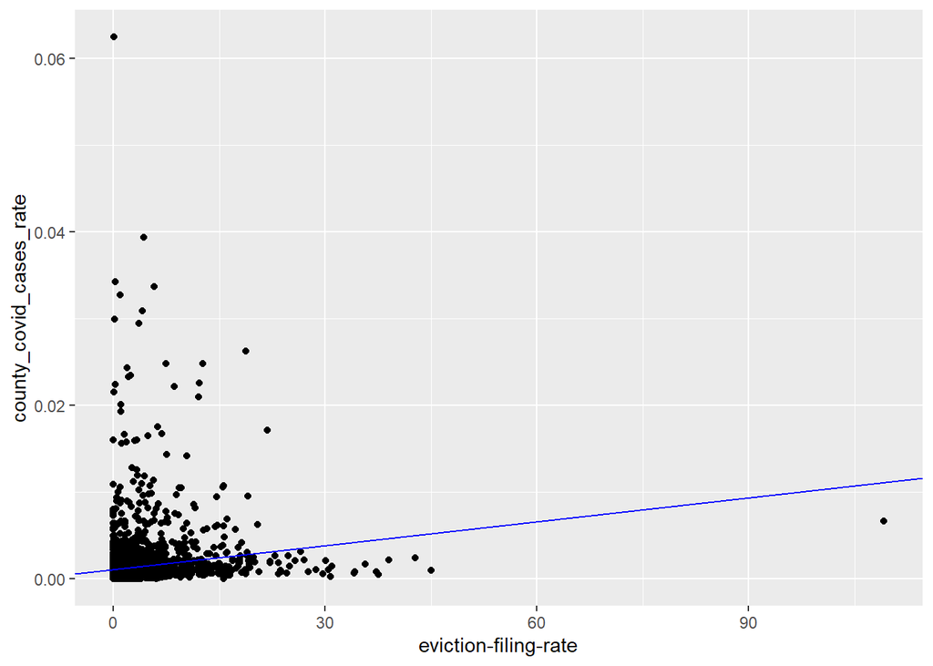

```r
covid.eviction %>%
  ggplot(aes(x = `eviction-filing-rate`,
             y = county_covid_cases_rate)) +
  geom_point() +
  geom_abline(slope = 9.185e-05, intercept = 1.121e-03, col = 'blue')
```

Even though our coefficient ws significant, by looking at the fitted line plotted against the actual values from in our data tells us that our points are really clustered at the lower covid and eviction case rates, with just a couple outliers that are really skewing our fitted model. From a visual perspective, this lm does not fit the data well, so I wouldn’t trust this model to make predictions about COVID cases based on eviction filing rates. Perhaps this means that a non-linear model would work best, but we can also try adding in additional control and interaction terms to see if the model changes.

```r
sumstats <- stat.desc(covid.eviction %>%
                    dplyr::select(`poverty-rate`, `renter-occupied-households`, `pct-renter-occupied`, `median-gross-rent`, `median-household-income`, `median-property-value`, `rent-burden`, `pct-white`, `pct-af-am`, `pct-hispanic`, `pct-am-ind`, `pct-asian`, `pct-multiple`, `eviction-filing-rate`, county_covid_cases_rate, county_covid_death_rate))
sumstats[c(4, 8, 9, 5, 13), ]
```

```
##         poverty-rate renter-occupied-households pct-renter-occupied
## min         0.000000                      15.00            7.350000
## median     11.310000                    2888.00           27.290000
## mean       12.203381                   14440.12           28.586609
## max        44.320000                 1792186.00           96.300000
## std.dev     5.748387                   55529.87            8.155774
##         median-gross-rent median-household-income median-property-value
## min              275.0000                19328.00              32300.00
## median           653.0000                45112.50             111900.00
## mean             700.7557                46836.91             133647.50
## max             1827.0000               123453.00             902500.00
## std.dev          191.6848                12247.72              77987.08
##         rent-burden pct-white pct-af-am pct-hispanic pct-am-ind pct-asian
## min       10.000000   0.95000  0.000000     0.000000   0.000000  0.000000
## median    28.800000  84.65000  2.090000     3.740000   0.260000  0.540000
## mean      28.509392  77.30806  8.881694     8.828389   1.737275  1.259465
## max       50.000000  99.76000 85.950000    98.710000  87.380000 41.640000
## std.dev    4.568922  19.87860 14.391028    13.496955   7.158680  2.659009
##         pct-multiple eviction-filing-rate county_covid_cases_rate
## min         0.000000             0.000000            0.0000000000
## median      1.470000             1.570000            0.0006014465
## mean        1.808488             3.079255            0.0014880331
## max        23.450000           109.160000            0.0625000000
## std.dev     1.700525             4.941657            0.0032365822
##         county_covid_death_rate
## min                  0.00000000
## median               0.01003018
## mean                 0.03679107
## max                  1.00000000
## std.dev              0.06992602
```

Looking at the summary statistics, we see that covid case rates range from 0 to 6.25% of county populations. Eviction filing rates range from 0 to 109.16 (total eviction filings/number of renter-occupued households). Our lm doesn’t estimate COVID rates above around 1%, meaning our model would never predict a covid case rate above around 1%, when in reality we see much higher rates ocurring. This further suggests that there are limitations to using a simple linear model to predict on our data.

How can we improve this linear model? If we still care about eviction rates, we can look at what other varibles may be able to explain additional variation in COVID cases and if our eviction rate variable remains significant. Adding control variables and interaction terms can add more depth to our understanding of the relationships in our data.

## Let’s look at the correlation between our variables:

```r
corr <- round(cor(covid.eviction %>%
                    dplyr::select(`poverty-rate`, `renter-occupied-households`, `pct-renter-occupied`, `median-gross-rent`, `median-household-income`, `median-property-value`, `rent-burden`, `pct-white`, `pct-af-am`, `pct-hispanic`, `pct-am-ind`, `pct-asian`, `pct-multiple`, `eviction-filing-rate`, county_covid_cases_rate, county_covid_death_rate), use = 'complete.obs'), 2)

corr[upper.tri(corr)] <- ""
corr <- as.data.frame(corr)
print(kable(corr), type = "latex", comment = FALSE)
```

[output not shown]

# Long LM Model Using High Correlation Variables

```r
lm2 <- lm(county_covid_cases_rate ~ `eviction-filing-rate` + `pct-white` + `pct-asian` +  `pct-renter-occupied` + `median-gross-rent`,
          data = covid.eviction)
summary(lm2)
```

```
##
## Call:
## lm(formula = county_covid_cases_rate ~ `eviction-filing-rate` +
##     `pct-white` + `pct-asian` + `pct-renter-occupied` + `median-gross-rent`,
##     data = covid.eviction)
##
## Residuals:
##       Min        1Q    Median        3Q       Max
## -0.005676 -0.000982 -0.000497  0.000042  0.061098
##
## Coefficients:
##                          Estimate Std. Error t value Pr(>|t|)
## (Intercept)             1.669e-03  5.150e-04   3.240  0.00121 **
## `eviction-filing-rate`  3.587e-05  1.288e-05   2.784  0.00541 **
## `pct-white`            -2.548e-05  3.516e-06  -7.246 5.57e-13 ***
## `pct-asian`             4.692e-05  3.072e-05   1.527  0.12680
## `pct-renter-occupied`   6.971e-06  8.817e-06   0.791  0.42924
## `median-gross-rent`     1.982e-06  4.150e-07   4.774 1.90e-06 ***
## ---
## Signif. codes:  0 '***' 0.001 '**' 0.01 '*' 0.05 '.' 0.1 ' ' 1
##
## Residual standard error: 0.003036 on 2702 degrees of freedom
##   (433 observations deleted due to missingness)
## Multiple R-squared:  0.0738, Adjusted R-squared:  0.07209
## F-statistic: 43.06 on 5 and 2702 DF,  p-value: < 2.2e-16
```

## Adjusted R-squared:

As we can see in our output, basing our independent variables off of correlations alone helped some but didn’t drastically increase Adjusted R-squared and gave us a couple of insignificant variables. We could just add and remove variables until we felt the R-squared was optimal, but that would take a lot of time so we can use the stepwise function to do that for us.

An additional strength of the stepwise function is that it optimizes models based on AIC rather than relying on R-squared and F-stats alone.

# Stepwise Long LM with Interaction Terms

```r
covid.eviction.naomit <- na.omit(covid.eviction %>%
                                   dplyr::select(`poverty-rate`, `renter-occupied-households`, `pct-renter-occupied`, `median-gross-rent`, `median-household-income`, `median-property-value`, `rent-burden`, `pct-white`, `pct-af-am`, `pct-hispanic`, `pct-am-ind`, `pct-asian`, `pct-multiple`, `eviction-filing-rate`, county_covid_cases_rate))

full.lm <- lm(county_covid_cases_rate ~.,
              data = covid.eviction.naomit)

step.lm <- stepAIC(full.lm,
                   scope = . ~ .^2,
                   direction = "both",
                   trace = FALSE)
summary(step.lm)
```

```
##
## Call:
## lm(formula = county_covid_cases_rate ~ `poverty-rate` + `renter-occupied-households` +
##     `pct-renter-occupied` + `median-gross-rent` + `median-household-income` +
##     `median-property-value` + `rent-burden` + `pct-white` + `pct-af-am` +
##     `pct-hispanic` + `pct-am-ind` + `pct-asian` + `pct-multiple` +
##     `eviction-filing-rate` + `pct-hispanic`:`eviction-filing-rate` +
##     `pct-af-am`:`eviction-filing-rate` + `renter-occupied-households`:`pct-multiple` +
##     `median-property-value`:`rent-burden` + `renter-occupied-households`:`pct-hispanic` +
##     `renter-occupied-households`:`median-property-value` + `median-gross-rent`:`pct-asian` +
##     `pct-hispanic`:`pct-asian` + `median-household-income`:`median-property-value` +
##     `renter-occupied-households`:`pct-asian` + `median-gross-rent`:`median-property-value` +
##     `poverty-rate`:`pct-af-am` + `pct-hispanic`:`pct-multiple` +
##     `pct-am-ind`:`pct-asian` + `rent-burden`:`pct-asian` + `median-gross-rent`:`pct-hispanic` +
##     `median-property-value`:`pct-hispanic` + `median-household-income`:`pct-hispanic` +
##     `renter-occupied-households`:`rent-burden` + `renter-occupied-households`:`median-household-income` +
##     `renter-occupied-households`:`pct-renter-occupied` + `median-gross-rent`:`median-household-income` +
##     `median-household-income`:`rent-burden` + `pct-af-am`:`pct-multiple` +
##     `pct-white`:`pct-af-am` + `poverty-rate`:`renter-occupied-households` +
##     `renter-occupied-households`:`pct-af-am` + `renter-occupied-households`:`pct-white` +
##     `renter-occupied-households`:`pct-am-ind` + `pct-asian`:`eviction-filing-rate` +
##     `median-property-value`:`pct-asian` + `pct-renter-occupied`:`median-household-income` +
##     `renter-occupied-households`:`eviction-filing-rate`, data = covid.eviction.naomit)
##
## Residuals:
##       Min        1Q    Median        3Q       Max
## -0.009185 -0.000838 -0.000373  0.000218  0.059674
##
## Coefficients:
##                                                          Estimate
## (Intercept)                                             6.886e-03
## `poverty-rate`                                          1.497e-05
## `renter-occupied-households`                            2.620e-06
## `pct-renter-occupied`                                  -8.218e-05
## `median-gross-rent`                                     1.172e-05
## `median-household-income`                              -1.201e-07
## `median-property-value`                                -4.871e-08
## `rent-burden`                                          -2.206e-04
## `pct-white`                                            -1.564e-05
## `pct-af-am`                                            -2.419e-05
```

[output cut: 127 more lines]

```
## `pct-white`:`pct-af-am`                                0.030093 *
## `poverty-rate`:`renter-occupied-households`            0.000194 ***
## `renter-occupied-households`:`pct-af-am`               3.87e-06 ***
## `renter-occupied-households`:`pct-white`               5.54e-06 ***
## `renter-occupied-households`:`pct-am-ind`              0.000148 ***
## `pct-asian`:`eviction-filing-rate`                     0.004569 **
## `median-property-value`:`pct-asian`                    0.018881 *
## `pct-renter-occupied`:`median-household-income`        0.014835 *
## `renter-occupied-households`:`eviction-filing-rate`    0.055803 .
## ---
## Signif. codes:  0 '***' 0.001 '**' 0.01 '*' 0.05 '.' 0.1 ' ' 1
##
## Residual standard error: 0.002753 on 2657 degrees of freedom
## Multiple R-squared:  0.2508, Adjusted R-squared:  0.2376
## F-statistic: 18.93 on 47 and 2657 DF,  p-value: < 2.2e-16
```

According to the step function, this is the optimal formula for an lm with interaction terms and controls. But this model shows that nearly every variable is significant and significantly interacts with another. What are we supposed to do with this information? If we have all variable information available for a given county, it may give us a precise prediction of covid case rates. However, the many NAs in our dataset mean that a lot of counties would not have enough of these variables observed to make a prediction using this model (rows are removed entirely if any NAs are observed). This may hint that our model is overfitting our data.

In addition, multiple linear regression models are difficult to visualize. A 3-D plane could be constructed to view a model with two independent variables, but beyond that, there isn’t much we can do to understand our data visually. In ADDITION, interaction terms make the entire model less interpretable. We can no longer interpret the coefficient on any variable “holding all else constant”. So while we maybe gain precision, we lose interpretability as well as the likelihood that our model can be used to accurately predict on new data.

Without interaction terms, the step function actually isn’t too bad at fitting a model. But again, we can’t really visualize it and really just have to hope that it can produce accurate predictions.

## Adjusted R-squared

Our Adjusted R-squared value increased to 0.23, meaning variations in the model explain about 23% of variations in Covid case rates, but our F-statistic decreased. It’s still significant, but it may suggest that our model overall isn’t as strong.

## F-statistic

Our F-statistic is reduced but still statistically significant.

Overall, using a stepwise function to find the best lm is not optimal because it results in overfitting, chooses models based on AIC rather than other significance measures, and as a result includes insignificant variables.

# Stepwise Long LM without Interaction Terms

```r
step.lm2 <- stepAIC(full.lm,
                   direction = "both",
                   trace = FALSE)
summary(step.lm2)
```

```
##
## Call:
## lm(formula = county_covid_cases_rate ~ `poverty-rate` + `renter-occupied-households` +
##     `pct-renter-occupied` + `median-household-income` + `median-property-value` +
##     `pct-af-am` + `pct-hispanic` + `pct-multiple`, data = covid.eviction.naomit)
##
## Residuals:
##       Min        1Q    Median        3Q       Max
## -0.007660 -0.000970 -0.000457  0.000087  0.060444
##
## Coefficients:
##                                Estimate Std. Error t value Pr(>|t|)
## (Intercept)                  -2.614e-03  5.426e-04  -4.818 1.53e-06 ***
## `poverty-rate`                6.604e-05  1.754e-05   3.765  0.00017 ***
## `renter-occupied-households`  3.092e-09  1.148e-09   2.693  0.00713 **
## `pct-renter-occupied`         1.423e-05  8.920e-06   1.595  0.11090
## `median-household-income`     4.037e-08  9.122e-09   4.426 9.99e-06 ***
## `median-property-value`       5.317e-09  1.190e-09   4.470 8.15e-06 ***
## `pct-af-am`                   4.242e-05  5.041e-06   8.414  < 2e-16 ***
## `pct-hispanic`                1.446e-05  4.927e-06   2.935  0.00336 **
## `pct-multiple`               -1.504e-04  3.505e-05  -4.290 1.85e-05 ***
## ---
## Signif. codes:  0 '***' 0.001 '**' 0.01 '*' 0.05 '.' 0.1 ' ' 1
##
## Residual standard error: 0.002977 on 2696 degrees of freedom
## Multiple R-squared:  0.1112, Adjusted R-squared:  0.1085
## F-statistic: 42.15 on 8 and 2696 DF,  p-value: < 2.2e-16
```

## Adjusted R-squared

Our Adjusted R-sqared term increased from 0.02 in our simple lm to 0.11 here. It’s still lower the 0.24 value we got from our long lm including interaction terms, meaning it explains less of the data. However, with fewer variables and no interaction terms, coefficients are relatively easy to interpret and we gain some ability to explain variations in COVID case rates.

## F-statistic:

Our F-statistic jumps up again, suggesting that this model is still relatively strong and our R-squared is significantly different from 0.

## Significance of our initial independent variable of interest

Eviction filing rates are no longer significant in this model, which highlights how lms can actually be helpful in identifying important variables so you don’t have to guess yourself. However, we are no longer answering our question and cannot make meaningful conclusions about our hypotheses.

One downside to all of these linear models using a continuous dependent variable is that we can’t measure accuracy as we can with other types of predictive models. To adjust our model to allow us to do this, we can perform a logit using a binary dependent variable: Whether Covid cases at the county level are greater than the state average.

# Simple Logistic Regression

```r
logit.model <- glm(covidCases_greater_state ~ `eviction-filing-rate`,
                   family = 'binomial',
                   data = covid.eviction)

summary(logit.model)
```

```
##
## Call:
## glm(formula = covidCases_greater_state ~ `eviction-filing-rate`,
##     family = "binomial", data = covid.eviction)
##
## Deviance Residuals:
##     Min       1Q   Median       3Q      Max
## -1.7567  -0.7690  -0.7347   1.3781   1.7120
##
## Coefficients:
##                         Estimate Std. Error z value Pr(>|z|)
## (Intercept)            -1.202928   0.053890 -22.322  < 2e-16 ***
## `eviction-filing-rate`  0.055702   0.009084   6.132 8.67e-10 ***
## ---
## Signif. codes:  0 '***' 0.001 '**' 0.01 '*' 0.05 '.' 0.1 ' ' 1
##
## (Dispersion parameter for binomial family taken to be 1)
##
##     Null deviance: 3101.5  on 2680  degrees of freedom
## Residual deviance: 3061.3  on 2679  degrees of freedom
##   (460 observations deleted due to missingness)
## AIC: 3065.3
##
## Number of Fisher Scoring iterations: 4
```

# AIC

Because we only have one dependent variable, it’s pretty easy to visualize:

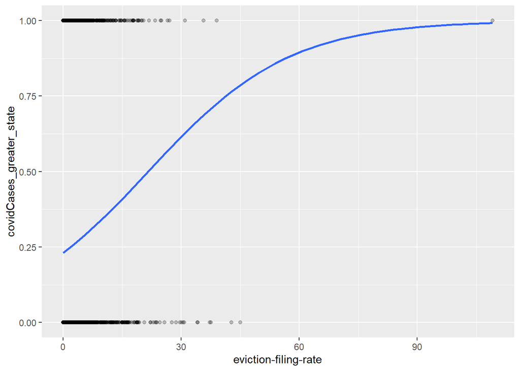

```r
covid.eviction %>%
  ggplot(aes(x = `eviction-filing-rate`,
             y = covidCases_greater_state)) +
  geom_point(alpha = 0.25) +
  stat_smooth(method = "glm",
              method.args = list(family = "binomial"),
              se = FALSE)
```

I will make predictions on the data, round the predictions to 0 or 1, and compare with actual covidCases_Greater_State values to measure accuracy.

```r
# subsetting original data to train & test
ran <- sample(1:nrow(covid.eviction), 0.9 * nrow(covid.eviction))

covid.eviction2 <- covid.eviction[, c(21, 41)] %>%
  na.omit()

train <- covid.eviction2[ran, ]
test <- covid.eviction2[-ran, 1]
# train.cl <- covid.eviction2[ran, 2]
test.cl <- covid.eviction2[-ran, 2]

# # making sure dependent variable is read as factor
# train.cl$covidCases_greater_state <- as.factor(train.cl$covidCases_greater_state)
# test.cl$covidCases_greater_state <- as.factor(test.cl$covidCases_greater_state)

train.logit.model <- glm(covidCases_greater_state ~ `eviction-filing-rate`,
                   family = 'binomial',
                   data = train)

# creating column of predictions
logit.predict <- test %>%
  mutate(prediction = round(predict.glm(train.logit.model,
                          newdata = test,
                          type = 'response')))

# confusion matrix
cm1 <- confusionMatrix(as.factor(logit.predict$prediction), as.factor(test.cl$covidCases_greater_state))
logit.accuracy <- 0.7509
logit.kappa <- -0.0057

print(cm1)
```

```
## Confusion Matrix and Statistics
##
##           Reference
## Prediction   0   1
##          0 180  81
##          1   2   0
##
##                Accuracy : 0.6844
##                  95% CI : (0.6245, 0.7401)
##     No Information Rate : 0.692
##     P-Value [Acc > NIR] : 0.6336
##
##                   Kappa : -0.0151
##
##  Mcnemar's Test P-Value : <2e-16
##
##             Sensitivity : 0.9890
##             Specificity : 0.0000
##          Pos Pred Value : 0.6897
##          Neg Pred Value : 0.0000
##              Prevalence : 0.6920
##          Detection Rate : 0.6844
##    Detection Prevalence : 0.9924
##       Balanced Accuracy : 0.4945
##
##        'Positive' Class : 0
##
```

## Precision:

```r
logit.precision <- precision(cm1$table)
print(logit.precision)
```

```
## [1] 0.6896552
```

Relatively high precision (positive predictive value) demonstrates that this model tells us that the fraction of relevant predictions (true positives) out of all predictions (true positives + false positives) is somewhat high. While there are false positives reflected in our denominator, we’re not too worried about that with a covid model. It might be better to have false positives than false negatives. Because this value is still less than 1, it means not all results retreived by our model were relevant.

## Recall:

```r
logit.recall <- recall(cm1$table)
print(logit.recall)
```

```
## [1] 0.989011
```

## Recall

The recall value represents how well our model retreives relevant instances: true positives & false negatives. We care about false negatives because we really would not want our model to produce much of that if we were using it to predict areas with covid strains. Our super high recall value shows us that our model retrieved almost all relevant instances.

## F-measure:

Since we really can’t cay for sure whether it’s better to have false negatives (county doesn’t receive attention) or false positives (diversion of attention from counties that actually need it to ones that don’t), we can weigh the overall precision and recall of the model using a beta of 1, meaning recall and precision are equally weighted.

```r
logit.f <- F_meas(cm1$table)
logit.matrix <- data.frame(Measure = c("Accuracy", "Precision", "Recall", "F-measure", "Kappa"),
                           Value = c(logit.accuracy, logit.precision, logit.recall, logit.f,
                                     logit.kappa))
print(logit.f)
```

```
## [1] 0.8126411
```

# 2. KNN

For my KNN function, I am using accuracy as my initial metric for optimization. Because there is a tradeoff between increasing values of K and reducing the number of classes, and a tradeoff between reducing values of K and response to variation in the data, I make this decision by plotting accuracies of our KNN function at various K’s (1-10) and choose the smallest K at which marginal increase in accuracy seems to taper off.

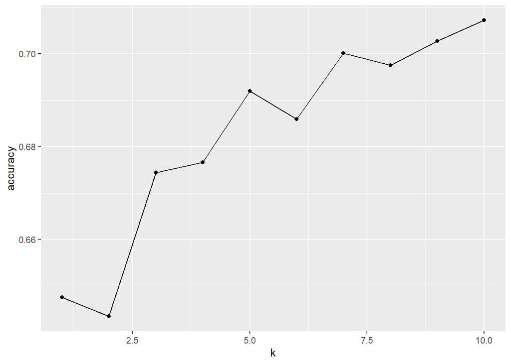

```r
# create function to normalize axis to improve distance calculations
normalize.function <- function(x){
  (x - min(x))/(max(x) - min(x))
}

# extracting columns of interest based on lm models, in this case eviction filing rates and percentage of residents who are african american
covid.eviction2 <- covid.eviction[, c(11, 21, 41)] %>%
  na.omit()

# applying normalization function to variables of interest
ce2 <- covid.eviction2
ce2$pct.af.am <- normalize.function(ce2$`pct-af-am`)
ce2$eviction.filing.rate <- normalize.function(ce2$`eviction-filing-rate`)

# run loop through ks 1-20 and graph to find optimal K (where additional k has significant marginal effect on accuracy)
store <- NULL
accuracy <- NULL

# because this seems to take forever, I'm limiting k to 10
for(k in 1:10){

  for(i in 1:nrow(ce2)){

    train <- ce2[-i,]
    test <- ce2[i,]

    prediction <- knn(train = train %>%
                        dplyr::select(pct.af.am, eviction.filing.rate),
                      test = test %>%
                        dplyr::select(pct.af.am, eviction.filing.rate),
                      train$covidCases_greater_state,
                      k)

    store[i] <- ifelse(prediction == ce2$covidCases_greater_state[i],
                       1,
                       0)

  }

  accuracy[k] <- mean(store)

    }

k <- (1:10)

find.k <- data.frame(k, accuracy)

find.k %>%
  ggplot(aes(x = k, y = accuracy)) +
  geom_point() +
  geom_line()
```

We’ll go with k = 5, 7, and 10.

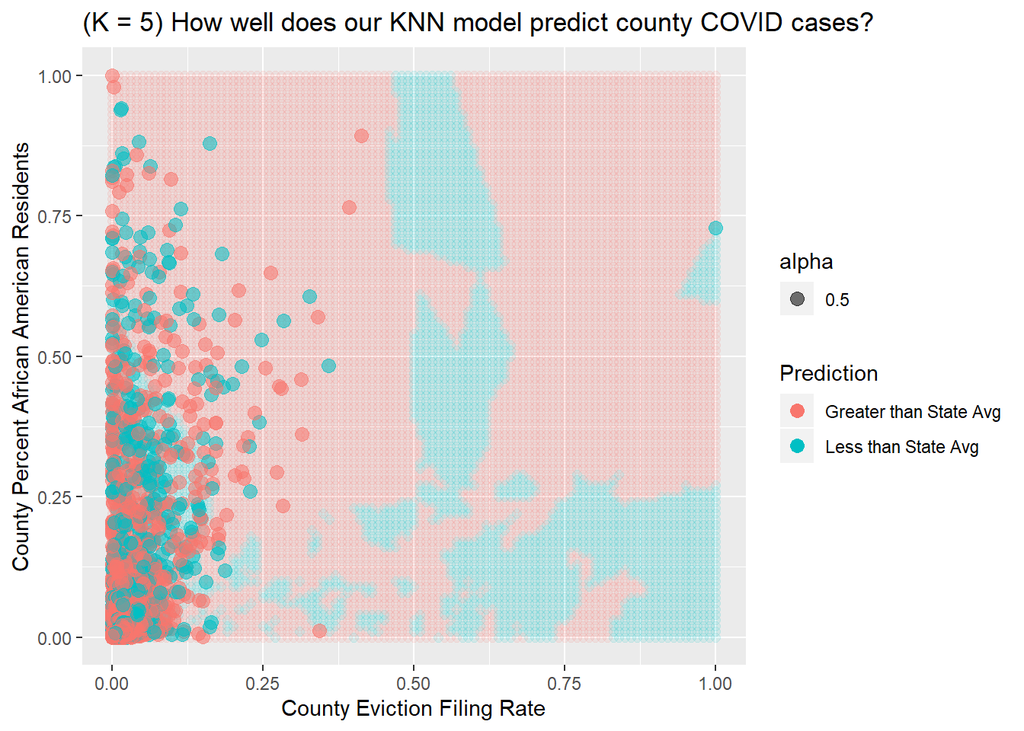

```r
# create a grid of normalized values within the range of our training data for visualization:
eviction.norm.seq <- seq(from = 0, to = 1, by = .01)
afam.norm.seq <- seq(from = 0, to = 1, by = .01)
norm.grid <- expand.grid(eviction.norm.seq, afam.norm.seq)
colnames(norm.grid)[c(1,2)] <- c('eviction.filing.rate', 'pct.af.am')

knn.grid <- norm.grid %>%
  mutate(prediction = knn(train = ce2 %>%
                            dplyr::select(pct.af.am, eviction.filing.rate),
                          test = norm.grid,
                          ce2$covidCases_greater_state,
                          5))

knn.grid %>%
  ggplot(aes(x = eviction.filing.rate,
             y = pct.af.am)) +
  geom_point(aes(color = factor(prediction)),
             size = 2,
             alpha = 0.1) +
  geom_point(data = ce2,
             mapping = aes(x = eviction.filing.rate,
                           y = pct.af.am,
                           color = factor(covidCases_greater_state),
                           alpha = 0.5),
             size = 3) +
  xlab('County Eviction Filing Rate') +
  ylab('County Percent African American Residents') +
  ggtitle('(K = 5) How well does our KNN model predict county COVID cases?') +
  scale_color_discrete(name = "Prediction", labels = c("Greater than State Avg", "Less than State Avg"))
```

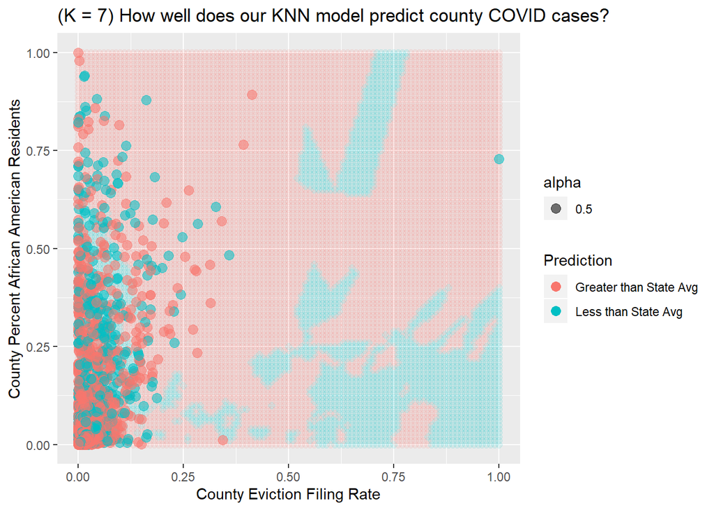

```r
knn.grid <- norm.grid %>%
  mutate(prediction = knn(train = ce2 %>%
                            dplyr::select(pct.af.am, eviction.filing.rate),
                          test = norm.grid,
                          ce2$covidCases_greater_state,
                          7))

knn.grid %>%
  ggplot(aes(x = eviction.filing.rate,
             y = pct.af.am)) +
  geom_point(aes(color = factor(prediction)),
             size = 2,
             alpha = 0.1) +
  geom_point(data = ce2,
             mapping = aes(x = eviction.filing.rate,
                           y = pct.af.am,
                           color = factor(covidCases_greater_state),
                           alpha = 0.5),
             size = 3) +
  xlab('County Eviction Filing Rate') +
  ylab('County Percent African American Residents') +
  ggtitle('(K = 7) How well does our KNN model predict county COVID cases?') +
  scale_color_discrete(name = "Prediction", labels = c("Greater than State Avg", "Less than State Avg"))
```

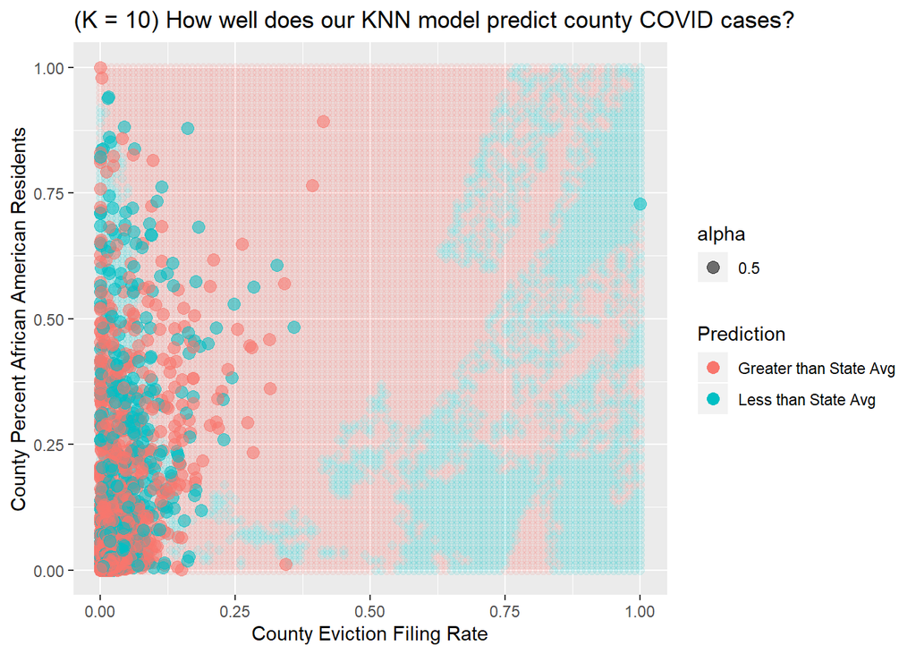

```r
knn.grid <- norm.grid %>%
  mutate(prediction = knn(train = ce2 %>%
                            dplyr::select(pct.af.am, eviction.filing.rate),
                          test = norm.grid,
                          ce2$covidCases_greater_state,
                          10))

knn.grid %>%
  ggplot(aes(x = eviction.filing.rate,
             y = pct.af.am)) +
  geom_point(aes(color = factor(prediction)),
             size = 2,
             alpha = 0.1) +
  geom_point(data = ce2,
             mapping = aes(x = eviction.filing.rate,
                           y = pct.af.am,
                           color = factor(covidCases_greater_state),
                           alpha = 0.5),
             size = 3) +
  xlab('County Eviction Filing Rate') +
  ylab('County Percent African American Residents') +
  ggtitle('(K = 10) How well does our KNN model predict county COVID cases?') +
  scale_color_discrete(name = "Prediction", labels = c("Greater than State Avg", "Less than State Avg"))
```

Looking at this plot, we can see that there are a lot of blue predicitons ocurring between 0.50 and 1.00 eviction filing rates where there aren’t any original data for all three K values. That suggests that our model would falsely predict a lot of ‘Less than state avg’ in places where we have no original data to confirm that to be true. This may be driven by an outlier in eviction filing rates near 1.00 (normalized). This suggests that a KNN model is less helpful in making predictions on values that it isn’t trained on. Applied to our real world example, if testing is largely done in counties with low eviction rates or eviction rates really are skewed so drastically, KNN may not be a great predictor for COVID case rates in underrepresented areas.

In addition, because we have so much data and it’s largely clustered in one third of the grid, it’s actually hard to tell what’s going on with our predictions behind the actual datapoints. Our two classes aren’t very clearly separated, which makes it difficult to get any meaningful separations using a KNN model.

How good is this KNN model by other measures?

## Confusion Matrix for KNN

```r
# subsetting original data to train & test
ran <- sample(1:nrow(ce2), 0.9 * nrow(ce2))

train <- ce2[ran, c(4,5)]
test <- ce2[-ran, c(4,5)]
train.cl <- ce2[ran, 3]
test.cl <- ce2[-ran, 3]

# making sure dependent variable is read as factor
train.cl$covidCases_greater_state <- as.factor(train.cl$covidCases_greater_state)
test.cl$covidCases_greater_state <- as.factor(test.cl$covidCases_greater_state)

# creating column of predictions
knn.predict.k5 <- test %>%
  mutate(prediction = knn(train = train,
                          test = test,
                          train.cl$covidCases_greater_state,
                          k = 5))

# creating column of predictions
knn.predict.k7 <- test %>%
  mutate(prediction = knn(train = train,
                          test = test,
                          train.cl$covidCases_greater_state,
                          k = 7))

# creating column of predictions
knn.predict.k10 <- test %>%
  mutate(prediction = knn(train = train,
                          test = test,
                          train.cl$covidCases_greater_state,
                          k = 10))

cm.k5 <- confusionMatrix(knn.predict.k5$prediction, test.cl$covidCases_greater_state)
accuracy.k5 <- 0.6952
precision.k5 <- precision(cm.k5$table)
recall.k5 <- recall(cm.k5$table)
f.k5 <- F_meas(cm.k5$table)
kappa.k5 <- as.data.table(cm.k5$overall)[2]

cm.k7 <- confusionMatrix(knn.predict.k7$prediction, test.cl$covidCases_greater_state)
accuracy.k7 <- 0.6952
precision.k7 <- precision(cm.k7$table)
recall.k7 <- recall(cm.k7$table)
f.k7 <- F_meas(cm.k7$table)
kappa.k7 <- as.data.table(cm.k7$overall)[2,]

cm.k10 <- confusionMatrix(knn.predict.k10$prediction, test.cl$covidCases_greater_state)
accuracy.k10 <- 0.6877
precision.k10 <- precision(cm.k10$table)
recall.k10 <- recall(cm.k10$table)
f.k10 <- F_meas(cm.k10$table)
kappa.k10 <- as.data.table(cm.k10$overall)[2,]

kappas <- c(kappa.k5, kappa.k7, kappa.k10)
kappas <- unlist(kappas, use.names = FALSE)

KNN.matrix <- data.frame(K = c(5, 7, 10),
  Accuracy = c(accuracy.k5, accuracy.k7, accuracy.k10),
  Precision = c(precision.k5, precision.k7, precision.k10),
  Recall = c(recall.k5, recall.k7, recall.k10),
  F_measure = c(f.k5, f.k7, f.k10),
  Kappa = kappas)

kable(KNN.matrix)
```

[output not shown]

## Precision:

Precision seems to decrease as K increases, suggesting a lower k is preferable when aiming for precision/a higher fraction of our retrieved instances to be relevant. These precision values are all higher than that of our logit model.

## Recall:

Recall increases as K increases, suggesting a higher k is preferable if we care more about a high recall/retrieving more of the total relevant instances. These recall values are all well below that of our logit model.

## Cohen’s Kappa:

The Kappas don’t seem to follow any particular pattern (they change every time the code is run), making it difficult to assess the true value of Kappa. Our kappas are all pretty low (below 0.20). Kappas of this value are considered ot have little to no agreement, meaning despite our other favorabl measures, these KNN models may not be much better at predicting than random chance. However, these kappas are all well above the negative kappa produced by our logit model.

#3.Single Decision Trees, Bagging, Boosting and Random Forests In this section, I will be comparing 4 different types of models: a single decision tree, bagging, boosting, and random forest. I will train these models on the training data, and will be using the testing data to examine each of their accuracy and Cohen’s Kappa.

## Create Training and Testing Data

Create two data, one for training the different models and the other for testing the models.

```r
#generate index for training data
index <- sample(nrow(covid.eviction),
                size = nrow(covid.eviction)*0.7,
                replace = FALSE)

#create training data
covid.eviction.train <- covid.eviction[index,]

#create testing data
covid.eviction.test <- covid.eviction[-index,]
```

## Single Decision Trees

Create 4 decision tree models for each of the 4 different outcome variables: covidCases_greater_state, covidCases_greater_US, covidDeaths_greater_state, covidDeaths_greater_US. The following also shows the decision trees generated for each of the models.

[figure not shown]

```r
#single decision tree model for covidCases_greater_state
tree.case.state <- rpart(
  factor(covidCases_greater_state) ~
    `eviction-filing-rate` +
    `poverty-rate` +
    `pct-renter-occupied` +
    `median-household-income` +
    `pct-white` +
    `pct-af-am` +
    `pct-hispanic` +
    `pct-asian` +
    `population`,
  data = covid.eviction.train
)

fancyRpartPlot(tree.case.state)
```

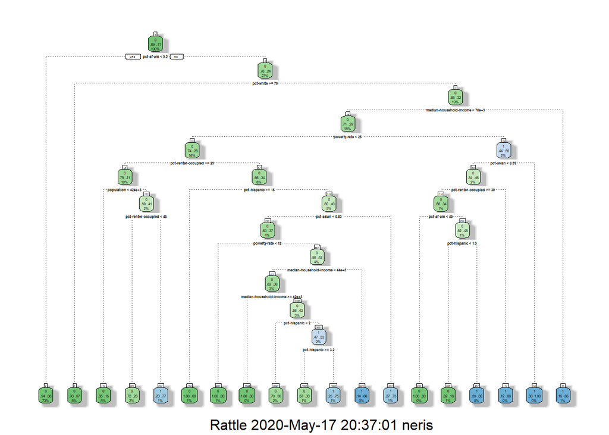

```r
#single decision tree model for covidCases_greater_US
tree.case.US <- rpart(
  factor(covidCases_greater_US) ~
    `eviction-filing-rate` +
    `poverty-rate` +
    `pct-renter-occupied` +
    `median-household-income` +
    `pct-white` +
    `pct-af-am` +
    `pct-hispanic` +
    `pct-asian` +
    `population`,
  data = covid.eviction.train
)

fancyRpartPlot(tree.case.US)
```

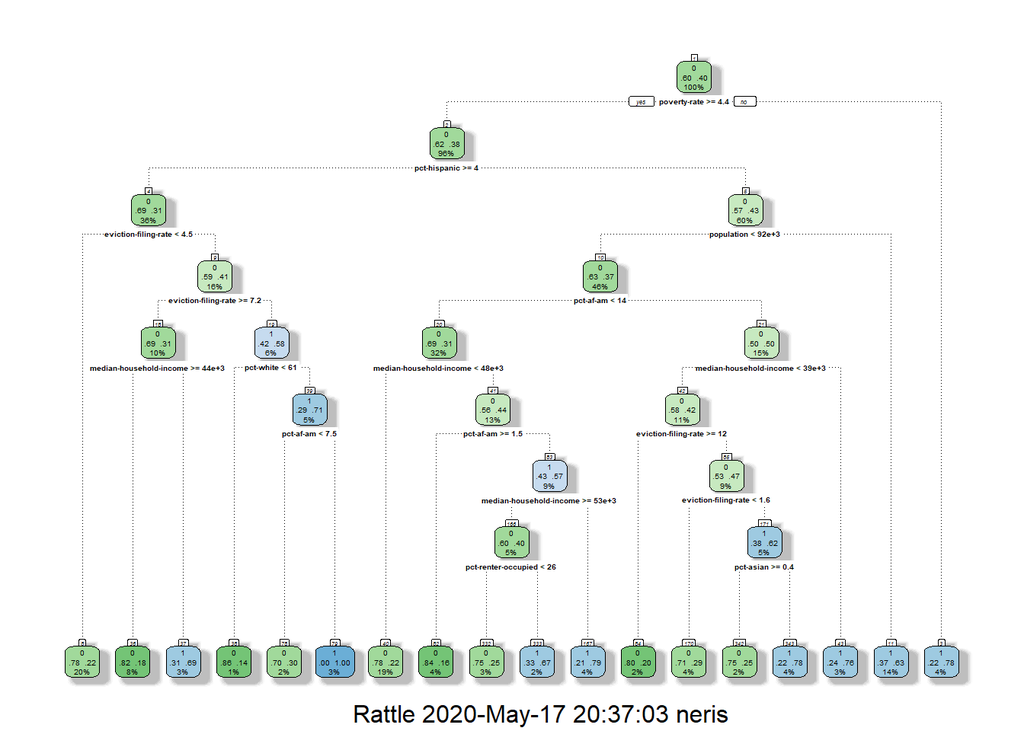

```r
#single decision tree model for covidDeaths_greater_state
tree.death.state <- rpart(
  factor(covidDeaths_greater_state) ~
    `eviction-filing-rate` +
    `poverty-rate` +
    `pct-renter-occupied` +
    `median-household-income` +
    `pct-white` +
    `pct-af-am` +
    `pct-hispanic` +
    `pct-asian` +
    `population`,
  data = covid.eviction.train
)

fancyRpartPlot(tree.death.state)
```

```r
#single decision tree model for covidDeaths_greater_US
tree.death.US <- rpart(
  factor(covidDeaths_greater_US) ~
    `eviction-filing-rate` +
    `poverty-rate` +
    `pct-renter-occupied` +
    `median-household-income` +
    `pct-white` +
    `pct-af-am` +
    `pct-hispanic` +
    `pct-asian` +
    `population`,
  data = covid.eviction.train
)

tree.death.US
```

```
## n=1975 (223 observations deleted due to missingness)
##
## node), split, n, loss, yval, (yprob)
##       * denotes terminal node
##
## 1) root 1975 450 0 (0.7721519 0.2278481) *
```

Amongst the four decision tree models, the last one, which uses covidDeaths_greater_US as the outcome, does not create a decision tree; it stops at the root node and does not split further. Below, I try to replicate this model but only using county-level data from a single state to check whether that produces decision trees.

[figure not shown]

```r
#single decision tree model of NY
tree.death.US.NY <- rpart(
  factor(covidDeaths_greater_US) ~
    `eviction-filing-rate` +
    `poverty-rate` +
    `pct-renter-occupied` +
    `median-household-income` +
    `pct-white` +
    `pct-af-am` +
    `pct-hispanic` +
    `pct-asian` +
    `population`,
  data = covid.eviction.train,
  subset = State == "NY",
  minsplit = 10
)

fancyRpartPlot(tree.death.US.NY)
```

[figure not shown]

```r
#single decision tree model of TX
tree.death.US.TX <- rpart(
  factor(covidDeaths_greater_US) ~
    `eviction-filing-rate` +
    `poverty-rate` +
    `pct-renter-occupied` +
    `median-household-income` +
    `pct-white` +
    `pct-af-am` +
    `pct-hispanic` +
    `pct-asian` +
    `population`,
  data = covid.eviction.train,
  subset = State == "TX",
  minsplit = 10
)

fancyRpartPlot(tree.death.US.TX)
```

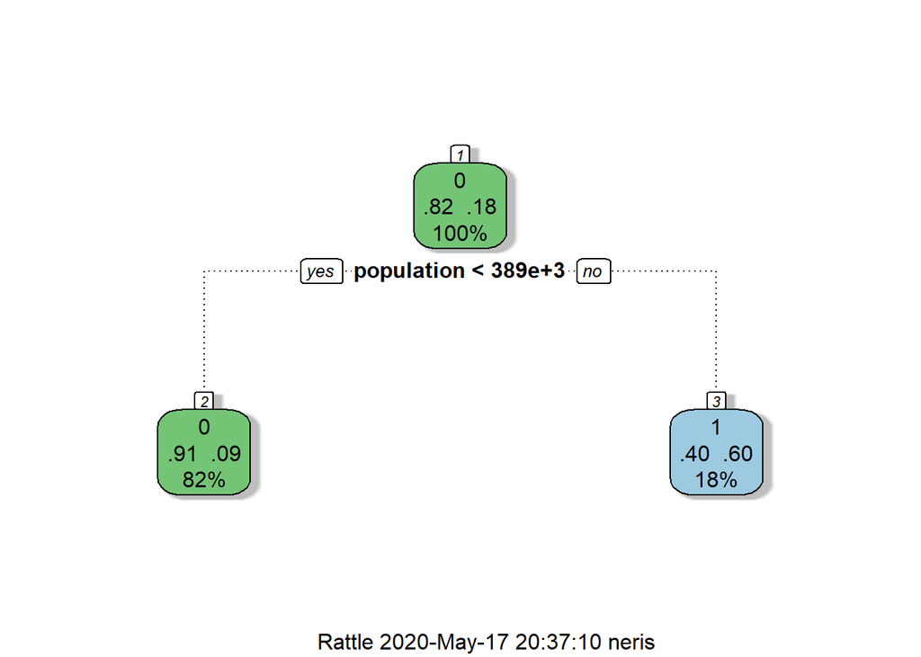

```r
#single decision tree model of WA
tree.death.US.WA <- rpart(
  factor(covidDeaths_greater_US) ~
    `eviction-filing-rate` +
    `poverty-rate` +
    `pct-renter-occupied` +
    `median-household-income` +
    `pct-white` +
    `pct-af-am` +
    `pct-hispanic` +
    `pct-asian` +
    `population`,
  data = covid.eviction.train,
  subset = State == "WA",
  minsplit = 10
)

fancyRpartPlot(tree.death.US.WA)
```

[figure not shown]

```r
#single decision tree model of MI
tree.death.US.MI <- rpart(
  factor(covidDeaths_greater_US) ~
    `eviction-filing-rate` +
    `poverty-rate` +
    `pct-renter-occupied` +
    `median-household-income` +
    `pct-white` +
    `pct-af-am` +
    `pct-hispanic` +
    `pct-asian` +
    `population`,
  data = covid.eviction.train,
  subset = State == "MI",
  minsplit = 10
)

fancyRpartPlot(tree.death.US.MI)
```

When using a state-level subset of the data (in this case: NY, TX, WA and MI), the models generate decision trees. It is suggested that when looking at the whole US data, the independent variables are not good predictors of whether then COVID-19 death rate of a county is greater than the US average, but when looking at the specific states, there are some independent variables that are good predictors of the outcome variable.

## Bagging

Create 4 bagging models for each of the outcome variables. I use the default number of trees in the built-in bagging model, which is 25 bootstrap replications. Below also shows the out-of-bag estimate of misclassification error.

```r
#bagging model for covidCases_greater_state
bagging.case.state <- bagging(
  factor(covidCases_greater_state) ~
    `eviction-filing-rate` +
    `poverty-rate` +
    `pct-renter-occupied` +
    `median-household-income` +
    `pct-white` +
    `pct-af-am` +
    `pct-hispanic` +
    `pct-asian` +
    `population`,
  data = covid.eviction.train,
  coob = TRUE
)

bagging.case.state
```

```
##
## Bagging classification trees with 25 bootstrap replications
##
## Call: bagging.data.frame(formula = factor(covidCases_greater_state) ~
##     `eviction-filing-rate` + `poverty-rate` + `pct-renter-occupied` +
##         `median-household-income` + `pct-white` + `pct-af-am` +
##         `pct-hispanic` + `pct-asian` + population, data = covid.eviction.train,
##     coob = TRUE)
##
## Out-of-bag estimate of misclassification error:  0.2832
```

```r
#bagging model for covidCases_greater_US
bagging.case.US <- bagging(
  factor(covidCases_greater_US) ~
    `eviction-filing-rate` +
    `poverty-rate` +
    `pct-renter-occupied` +
    `median-household-income` +
    `pct-white` +
    `pct-af-am` +
    `pct-hispanic` +
    `pct-asian` +
    `population`,
  data = covid.eviction.train,
  coob = TRUE
)

bagging.case.US
```

```
##
## Bagging classification trees with 25 bootstrap replications
##
## Call: bagging.data.frame(formula = factor(covidCases_greater_US) ~
##     `eviction-filing-rate` + `poverty-rate` + `pct-renter-occupied` +
##         `median-household-income` + `pct-white` + `pct-af-am` +
##         `pct-hispanic` + `pct-asian` + population, data = covid.eviction.train,
##     coob = TRUE)
##
## Out-of-bag estimate of misclassification error:  0.107
```

```r
#bagging model for covidDeaths_greater_state
bagging.death.state <- bagging(
  factor(covidDeaths_greater_state) ~
    `eviction-filing-rate` +
    `poverty-rate` +
    `pct-renter-occupied` +
    `median-household-income` +
    `pct-white` +
    `pct-af-am` +
    `pct-hispanic` +
    `pct-asian` +
    `population`,
  data = covid.eviction.train,
  coob = TRUE
)

bagging.death.state
```

```
##
## Bagging classification trees with 25 bootstrap replications
##
## Call: bagging.data.frame(formula = factor(covidDeaths_greater_state) ~
##     `eviction-filing-rate` + `poverty-rate` + `pct-renter-occupied` +
##         `median-household-income` + `pct-white` + `pct-af-am` +
##         `pct-hispanic` + `pct-asian` + population, data = covid.eviction.train,
##     coob = TRUE)
##
## Out-of-bag estimate of misclassification error:  0.4741
```

```r
#bagging model for covidDeaths_greater_US
bagging.death.US <- bagging(
  factor(covidDeaths_greater_US) ~
    `eviction-filing-rate` +
    `poverty-rate` +
    `pct-renter-occupied` +
    `median-household-income` +
    `pct-white` +
    `pct-af-am` +
    `pct-hispanic` +
    `pct-asian` +
    `population`,
  data = covid.eviction.train,
  coob = TRUE
)

bagging.death.US
```

```
##
## Bagging classification trees with 25 bootstrap replications
##
## Call: bagging.data.frame(formula = factor(covidDeaths_greater_US) ~
##     `eviction-filing-rate` + `poverty-rate` + `pct-renter-occupied` +
##         `median-household-income` + `pct-white` + `pct-af-am` +
##         `pct-hispanic` + `pct-asian` + population, data = covid.eviction.train,
##     coob = TRUE)
##
## Out-of-bag estimate of misclassification error:  0.2584
```

## Boosting

There are 4 different boosting models for each of the outcome variables. The number of trees is 25, which is the default number for the built-in adaboost function. The outcomes also show the weights of each of the trees.

```r
#boosting model for covidCases_greater_state
boosting.case.state <- adaboost(
  covidCases_greater_state ~
    eviction.filing.rate +
    poverty.rate +
    pct.renter.occupied +
    median.household.income +
    pct.white +
    pct.af.am +
    pct.hispanic +
    pct.asian +
    population,
  data = data.frame(covid.eviction.train),
  nIter = 25
)

boosting.case.state
```

```
## adaboost(formula = covidCases_greater_state ~ eviction.filing.rate +
##     poverty.rate + pct.renter.occupied + median.household.income +
##     pct.white + pct.af.am + pct.hispanic + pct.asian + population,
##     data = data.frame(covid.eviction.train), nIter = 25)
## covidCases_greater_state ~ eviction.filing.rate + poverty.rate +
##     pct.renter.occupied + median.household.income + pct.white +
##     pct.af.am + pct.hispanic + pct.asian + population
## Dependent Variable: covidCases_greater_state
## No of trees:25
## The weights of the trees are:0.81497710.80256350.75267660.7724750.76696370.77121760.76647830.78377470.7652190.82501920.77119420.83229880.79512410.76449170.7954110.79849770.7823070.79370340.74654840.77644120.79111370.79705140.78182760.78606970.7346897
```

```r
#boosting model for covidCases_greater_US
boosting.case.US <- adaboost(
  covidCases_greater_US ~
    eviction.filing.rate +
    poverty.rate +
    pct.renter.occupied +
    median.household.income +
    pct.white +
    pct.af.am +
    pct.hispanic +
    pct.asian +
    population,
  data = data.frame(covid.eviction.train),
  nIter = 25
)

boosting.case.US
```

```
## adaboost(formula = covidCases_greater_US ~ eviction.filing.rate +
##     poverty.rate + pct.renter.occupied + median.household.income +
##     pct.white + pct.af.am + pct.hispanic + pct.asian + population,
##     data = data.frame(covid.eviction.train), nIter = 25)
## covidCases_greater_US ~ eviction.filing.rate + poverty.rate +
##     pct.renter.occupied + median.household.income + pct.white +
##     pct.af.am + pct.hispanic + pct.asian + population
## Dependent Variable: covidCases_greater_US
## No of trees:25
## The weights of the trees are:1.2961131.0726231.0216131.0367940.91408760.96676410.93240170.96951690.91222080.91091290.92187150.93250660.94067260.92019830.94419130.87834740.9194570.94843170.78124860.96625840.98805460.95916160.89456660.84581660.8528279
```

```r
#boosting model for covidDeaths_greater_state
boosting.death.state <- adaboost(
  covidDeaths_greater_state ~
    eviction.filing.rate +
    poverty.rate +
    pct.renter.occupied +
    median.household.income +
    pct.white +
    pct.af.am +
    pct.hispanic +
    pct.asian +
    population,
  data = data.frame(covid.eviction.train),
  nIter = 25
)

boosting.death.state
```

```
## adaboost(formula = covidDeaths_greater_state ~ eviction.filing.rate +
##     poverty.rate + pct.renter.occupied + median.household.income +
##     pct.white + pct.af.am + pct.hispanic + pct.asian + population,
##     data = data.frame(covid.eviction.train), nIter = 25)
## covidDeaths_greater_state ~ eviction.filing.rate + poverty.rate +
##     pct.renter.occupied + median.household.income + pct.white +
##     pct.af.am + pct.hispanic + pct.asian + population
## Dependent Variable: covidDeaths_greater_state
## No of trees:25
## The weights of the trees are:0.69942080.64193440.66087430.60329120.63724080.65826620.70589270.64202030.6355090.74753860.66917930.69878740.70387540.69673190.68151580.63946240.74053550.64255910.63800690.72071060.68107480.65588680.6938230.76016270.63606
```

```r
#boosting model for covidDeaths_greater_US
boosting.death.US <- adaboost(
  covidDeaths_greater_US ~
    eviction.filing.rate +
    poverty.rate +
    pct.renter.occupied +
    median.household.income +
    pct.white +
    pct.af.am +
    pct.hispanic +
    pct.asian +
    population,
  data = data.frame(covid.eviction.train),
  nIter = 25
)

boosting.death.US
```

```
## adaboost(formula = covidDeaths_greater_US ~ eviction.filing.rate +
##     poverty.rate + pct.renter.occupied + median.household.income +
##     pct.white + pct.af.am + pct.hispanic + pct.asian + population,
##     data = data.frame(covid.eviction.train), nIter = 25)
## covidDeaths_greater_US ~ eviction.filing.rate + poverty.rate +
##     pct.renter.occupied + median.household.income + pct.white +
##     pct.af.am + pct.hispanic + pct.asian + population
## Dependent Variable: covidDeaths_greater_US
## No of trees:25
## The weights of the trees are:0.83100010.79235120.77974680.79157740.78784180.75971350.82020910.78872670.75051190.75313340.79233510.79028960.76640230.77446740.82367550.82278580.81774180.803990.8245060.80358530.67531080.81578360.77701640.78727760.8171721
```

## Random Forests

Again, there are 4 different random forest models for each of the outcome variables. The type of random forest is classification, and each model has 500 trees and 3 variables tried at each split. The outcome below shows out-of-bag estimate of error rate and the confusion matrix for each of the models.

```r
#random forest model for covidCases_greater_state
rf.case.state <- randomForest(
  factor(covidCases_greater_state) ~
    eviction.filing.rate +
    poverty.rate +
    pct.renter.occupied +
    median.household.income +
    pct.white +
    pct.af.am +
    pct.hispanic +
    pct.asian +
    population,
  data = data.frame(covid.eviction.train) %>%
    na.omit()
)

rf.case.state
```

```
##
## Call:
##  randomForest(formula = factor(covidCases_greater_state) ~ eviction.filing.rate +      poverty.rate + pct.renter.occupied + median.household.income +      pct.white + pct.af.am + pct.hispanic + pct.asian + population,      data = data.frame(covid.eviction.train) %>% na.omit())
##                Type of random forest: classification
##                      Number of trees: 500
## No. of variables tried at each split: 3
##
##         OOB estimate of  error rate: 25.68%
## Confusion matrix:
##     0  1 class.error
## 0 254 32   0.1118881
## 1  72 47   0.6050420
```

```r
#random forest model for covidCases_greater_US
rf.case.US <- randomForest(
  factor(covidCases_greater_US) ~
    eviction.filing.rate +
    poverty.rate +
    pct.renter.occupied +
    median.household.income +
    pct.white +
    pct.af.am +
    pct.hispanic +
    pct.asian +
    population,
  data = data.frame(covid.eviction.train) %>%
    na.omit()
)

rf.case.US
```

```
##
## Call:
##  randomForest(formula = factor(covidCases_greater_US) ~ eviction.filing.rate +      poverty.rate + pct.renter.occupied + median.household.income +      pct.white + pct.af.am + pct.hispanic + pct.asian + population,      data = data.frame(covid.eviction.train) %>% na.omit())
##                Type of random forest: classification
##                      Number of trees: 500
## No. of variables tried at each split: 3
##
##         OOB estimate of  error rate: 15.31%
## Confusion matrix:
##     0  1 class.error
## 0 310 13  0.04024768
## 1  49 33  0.59756098
```

```r
#random forest model for covidDeaths_greater_state
rf.death.state <- randomForest(
  factor(covidDeaths_greater_state) ~
    eviction.filing.rate +
    poverty.rate +
    pct.renter.occupied +
    median.household.income +
    pct.white +
    pct.af.am +
    pct.hispanic +
    pct.asian +
    population,
  data = data.frame(covid.eviction.train) %>%
    na.omit()
)

rf.death.state
```

```
##
## Call:
##  randomForest(formula = factor(covidDeaths_greater_state) ~ eviction.filing.rate +      poverty.rate + pct.renter.occupied + median.household.income +      pct.white + pct.af.am + pct.hispanic + pct.asian + population,      data = data.frame(covid.eviction.train) %>% na.omit())
##                Type of random forest: classification
##                      Number of trees: 500
## No. of variables tried at each split: 3
##
##         OOB estimate of  error rate: 45.19%
## Confusion matrix:
##     0  1 class.error
## 0 180 65   0.2653061
## 1 118 42   0.7375000
```

```r
#random forest model for covidDeaths_greater_US
rf.death.US <- randomForest(
  factor(covidDeaths_greater_US) ~
    eviction.filing.rate +
    poverty.rate +
    pct.renter.occupied +
    median.household.income +
    pct.white +
    pct.af.am +
    pct.hispanic +
    pct.asian +
    population,
  data = data.frame(covid.eviction.train) %>%
    na.omit()
)

rf.death.US
```

```
##
## Call:
##  randomForest(formula = factor(covidDeaths_greater_US) ~ eviction.filing.rate +      poverty.rate + pct.renter.occupied + median.household.income +      pct.white + pct.af.am + pct.hispanic + pct.asian + population,      data = data.frame(covid.eviction.train) %>% na.omit())
##                Type of random forest: classification
##                      Number of trees: 500
## No. of variables tried at each split: 3
##
##         OOB estimate of  error rate: 29.63%
## Confusion matrix:
##     0  1 class.error
## 0 270 20  0.06896552
## 1 100 15  0.86956522
```

## Test the Models on Testing Data

### Predict outcome on testing data using models

We predict the outcome of each variables for testing data using the models we generated above.

```r
#predictions for single decision tree models
tree.case.state.preds <-
  ifelse(predict(tree.case.state, covid.eviction.test)[, 2] > 0.5, 1, 0)
tree.case.US.preds <-
  ifelse(predict(tree.case.US, covid.eviction.test)[, 2] > 0.5, 1, 0)
tree.death.state.preds <-
  ifelse(predict(tree.death.state, covid.eviction.test)[, 2] > 0.5, 1, 0)
tree.death.US.preds <-
  ifelse(predict(tree.death.US, covid.eviction.test)[, 2] > 0.5, 1, 0)

#predictions for bagging models
bagging.case.state.preds <-
  predict(bagging.case.state, covid.eviction.test)
bagging.case.US.preds <-
  predict(bagging.case.US, covid.eviction.test)
bagging.death.state.preds <-
  predict(bagging.death.state, covid.eviction.test)
bagging.death.US.preds <-
  predict(bagging.death.state, covid.eviction.test)

#predictions for boosting models
boosting.case.state.preds <-
  predict(boosting.case.state, data.frame(covid.eviction.test))$class
boosting.case.US.preds <-
  predict(boosting.case.US, data.frame(covid.eviction.test))$class
boosting.death.state.preds <-
  predict(boosting.death.state, data.frame(covid.eviction.test))$class
boosting.death.US.preds <-
  predict(boosting.death.US, data.frame(covid.eviction.test))$class

#predictions for random forest models
rf.case.state.preds <-
  predict(rf.case.state, data.frame(covid.eviction.test))
rf.case.US.preds <-
  predict(rf.case.US, data.frame(covid.eviction.test))
rf.death.state.preds <-
  predict(rf.death.state, data.frame(covid.eviction.test))
rf.death.US.preds <-
  predict(rf.death.US, data.frame(covid.eviction.test))
```

### Function that corrects confusion matrix that is not 2x2

This function corrects confusion matrix that is not 2x2. In the case of our data, the tree.death.US model predicts all the outcomes to be 0, thus the confusion matrix is 1x2. This function corrects it to a 2x2 matrix, so that all confusion matrices would have the same dimensions.

```r
correct.cm <- function(confusion.matrix) {
  #Inputs:
  #confusion.matrix: confusion matrix, ideally 2x2, but could be 1x2 or 2x1

  #Output: return a corrected 2x2 confusion matrix as a table

  #check if confusion matrix is 2x2
  if (nrow(confusion.matrix) == 2 & ncol(confusion.matrix) == 2) {
    #if 2x2, nothing needs to be corrected
    corrected <- confusion.matrix

    #if 1x2 (missing row)
  } else if (nrow(confusion.matrix) == 1) {
    #check the rowname that exists vs missing
    if (rownames(confusion.matrix)[1] == 0) {
      #if outcome == 1 row is missing, add the row (0, 0) to the bottom
      corrected <- rbind(confusion.matrix, c(0, 0))
      rownames(corrected) <- c(0, 1)
      #if outcome == 0 row is missing, add the row (0, 0) to the top
    } else if (rownames(confusion.matrix)[1] == 1) {
      corrected <- rbind(c(0, 0), confusion.matrix)
      rownames(corrected) <- c(0, 1)
    }

    #if 2x1 (missing column)
  } else if (ncol(confusion.matrix) == 1) {
    #check the colname that exists vs missing
    if (colnames(confusion.matrix)[1] == 0) {
      #if outcome == 1 col is missing, add the col (0, 0) to the right
      corrected <- cbind(confusion.matrix, c(0, 0))
      colnames(corrected) <- c(0, 1)
      #if outcome == 0 col is missing, add the col (0, 0) to the left
    } else if (colnames(confusion.matrix)[1] == 1) {
      corrected <- cbind(c(0, 0), confusion.matrix)
      colnames(corrected) <- c(0, 1)
    }
  }

   #make sure that the final corrected matrix is in a table format
  corrected <- as.table(corrected)

  #return corrected 2x2 confusion matrix
  return(corrected)
}
```

### Create confusion matrices for each model

We create confusion matrices for each of the models, and use the function that corrects 1x2 or 2x1 matrices into a 2x2 matrix to make sure that all the matrices are of the same dimesion.

```r
#vector of 4 different model types
model.types <- c("tree", "bagging", "boosting", "rf")

#vector of 4 different outcome variables
outcome.vars <-
  c("case.state", "case.US", "death.state", "death.US")

#for loop to generate confusion matrices for each outcome variable using 4 different models
for (i in model.types) {
  for (j in outcome.vars) {

    #creates string variable with the confusion matrix name (eg. "cm.tree.case.state")
    cm <- paste("cm", i, j, sep = ".")

    #evaluates the prediction of each model (eg. tree.case.state.preds)
    preds <- eval(parse(text = paste(i, j, "preds", sep = ".")))

    #for each outcome variable, it assigns the confusion matrix table to 'cm'
    if (j == "case.state") {
      assign(cm,
             table(preds, covid.eviction.test$covidCases_greater_state))
    } else if (j == "case.US") {
      assign(cm,
             table(preds, covid.eviction.test$covidCases_greater_US))
    } else if (j == "death.state") {
      assign(cm,
             table(preds, covid.eviction.test$covidDeaths_greater_state))
    } else if (j == "death.US") {
      assign(cm,
             table(preds, covid.eviction.test$covidDeaths_greater_US))
    }

    #each confusion matrix generated above is corrected to a 2x2 table using the corrected.cm() function
    assign(cm, correct.cm(eval(as.name(cm))))
  }
}
```

# Accuracy Function

This function uses a 2x2 confusion matrix as an input to calculate the accuracy.

```r
accuracy <- function(confusion.matrix) {
  #Inputs:
  #confusion.matrix: confusion matrix of an algorithm (dimensions: 2x2)

  #Output: return accuracy

  #calculate accuracy (observed agreement)
  accuracy <-
    (confusion.matrix[1, 1] + confusion.matrix[2, 2]) / sum(confusion.matrix)

  return(accuracy)
}
```

# Cohen’s Kappa Function

This function uses a 2x2 confusion matrix as an input to calculate Cohen’s Kappa.

```r
kappa <- function(confusion.matrix) {
  #Inputs:
  #confusion.matrix: confusion matrix of an algorithm (dimensions: 2x2)

  #Output: return Cohen's kappa

  #calculate observed agreement (accuracy)
  Po <-
    (confusion.matrix[1, 1] + confusion.matrix[2, 2]) / sum(confusion.matrix)

  #calculate probability of agreement by random chance
  Pe <- 1 / sum(confusion.matrix) ^ 2 *
    (sum(confusion.matrix[1,] * sum(confusion.matrix[, 1])) +
       sum(confusion.matrix[2,] * sum(confusion.matrix[, 2])))

  #calculate Cohen's Kappa
  kappa = (Po - Pe) / (1 - Pe)

  return(kappa)
}
```

# Create a table to compare all models

We calculate the accuracy and the kappa of each model, and we use that to generate a comparison table that shows the accuracy and the kappa for each type of model for each outcome variable.

```r
#vector of 4 different outcome variables
outcome.vars <- c("case.state", "case.US", "death.state", "death.US")

#null vectors for single decision tree models' accuracy and kappa values
tree.accuracy <- NULL
tree.kappa <- NULL

#vectors for single decision tree models' accuracy values
tree.accuracy <- c(
  accuracy(cm.tree.case.state),
  accuracy(cm.tree.case.US),
  accuracy(cm.tree.death.state),
  accuracy(cm.tree.death.US)
)

#vectors for single decision tree models' kappa values
tree.kappa <- c(
  kappa(cm.tree.case.state),
  kappa(cm.tree.case.US),
  kappa(cm.tree.death.state),
  kappa(cm.tree.death.US)
)

#null vectors for bagging models' accuracy and kappa values
bagging.accuracy <- NULL
bagging.kappa <- NULL

#vectors for bagging models' accuracy values
bagging.accuracy <- c(
  accuracy(cm.bagging.case.state),
  accuracy(cm.bagging.case.US),
  accuracy(cm.bagging.death.state),
  accuracy(cm.bagging.death.US)
)

#vectors for bagging models' kappa values
bagging.kappa <- c(
  kappa(cm.bagging.case.state),
  kappa(cm.bagging.case.US),
  kappa(cm.bagging.death.state),
  kappa(cm.bagging.death.US)
)

#null vectors for boosting models' accuracy and kappa values
boosting.accuracy <- NULL
boosting.kappa <- NULL

#vectors for boosting models' accuracy values
boosting.accuracy <- c(
  accuracy(cm.boosting.case.state),
  accuracy(cm.boosting.case.US),
  accuracy(cm.boosting.death.state),
  accuracy(cm.boosting.death.US)
)

#vectors for boosting models' kappa values
boosting.kappa <- c(
  kappa(cm.boosting.case.state),
  kappa(cm.boosting.case.US),
  kappa(cm.boosting.death.state),
  kappa(cm.boosting.death.US)
)

#null vectors for random forest models' accuracy and kappa values
rf.accuracy <- NULL
rf.kappa <- NULL

#vectors for random forest models' accuracy values
rf.accuracy <- c(
  accuracy(cm.rf.case.state),
  accuracy(cm.rf.case.US),
  accuracy(cm.rf.death.state),
  accuracy(cm.rf.death.US)
)

#vectors for random forest models' kappa values
rf.kappa <- c(
  kappa(cm.rf.case.state),
  kappa(cm.rf.case.US),
  kappa(cm.rf.death.state),
  kappa(cm.rf.death.US)
)

#generate data frame of accuracy and kappa values of each models for different outcome variables
comparison <- data.frame(outcome.vars, tree.accuracy, tree.kappa, bagging.accuracy, bagging.kappa, boosting.accuracy, boosting.kappa, rf.accuracy, rf.kappa)

kable(comparison, digits = 3)
```

| outcome.vars | tree.accuracy | tree.kappa | bagging.accuracy | bagging.kappa | boosting.accuracy | boosting.kappa | rf.accuracy | rf.kappa |
| --- | --- | --- | --- | --- | --- | --- | --- | --- |
| case.state | 0.753 | 0.209 | 0.750 | 0.245 | 0.722 | 0.194 | 0.750 | 0.210 |
| case.US | 0.899 | 0.164 | 0.897 | 0.108 | 0.899 | 0.229 | 0.871 | 0.108 |
| death.state | 0.554 | 0.084 | 0.603 | 0.183 | 0.603 | 0.193 | 0.599 | 0.141 |
| death.US | 0.786 | 0.000 | 0.697 | 0.065 | 0.734 | 0.032 | 0.772 | 0.015 |

# 4. LDA

Similar to Logistic Regression, Linear Discriminant Analysis aims to decrease the dimensionality of a dataset. LDA is useful in predicting categorical variables. Specifically in the following case, I want to use LDA to answer the following question: 1. What line best separates STATES with COVID-death rates above the US national average from those with COVID-death rates below the national average?

```r
# LDA for STATES greater than NATIONAL
state.vs.national.death <- na.omit(covid.eviction %>%
  dplyr::select( -US_covid_cases_rate, -covidDeaths_greater_state,
         -US_covid_death_rate, -covidCases_greater_state,
         -county_covid_cases_rate, -county_covid_death_rate,
         -state_covid_cases_rate, -state_covid_death_rate,
         -covidDeaths, -covidCases, -evictions_greater_state,
         -evictions_greater_US, -covidCases_greater_US, -GEOID, -year,
         -`low-flag`, -imputed, -subbed, -stateFIPS, -County, -state_mean_filing_rate,
          -US_mean_filing_rate))

#let's create training and testing datasets
index <- sample(nrow(state.vs.national.death),
                size = nrow(state.vs.national.death),
                replace = TRUE)

s.v.n.train <- state.vs.national.death[index,]
s.v.n.test <- state.vs.national.death[-index,]

#Now, let's build an LDA model with the training dataset
lda1 <- lda(covidDeaths_greater_US ~ .,
            data = s.v.n.train %>%
              dplyr::select(-State),
            family = "binomal")

lda1
```

```
## Call:
## lda(covidDeaths_greater_US ~ ., data = s.v.n.train %>% dplyr::select(-State),
##     family = "binomal")
##
## Prior probabilities of groups:
##         0         1
## 0.7837717 0.2162283
##
## Group means:
##   `poverty-rate` `renter-occupied-households` `pct-renter-occupied`
## 0       12.17895                     16567.51              28.40690
## 1       12.28359                     17906.46              27.66767
##   `median-gross-rent` `median-household-income` `median-property-value`
## 0            700.9369                  46530.90                134198.9
## 1            728.1485                  46966.45                141669.1
##   `rent-burden` `pct-white` `pct-af-am` `pct-hispanic` `pct-am-ind`
## 0      28.74590    78.13636    8.922543       8.621786    1.1072696
## 1      29.67278    78.67241   11.011113       6.284619    0.8979794
##   `pct-asian` `pct-nh-pi` `pct-multiple` `pct-other` `eviction-filings`
## 0    1.294408  0.06875995       1.753766  0.09532992           919.8817
## 1    1.228619  0.05657732       1.746928  0.10142268          1343.7876
##   evictions `eviction-rate` `eviction-filing-rate` population
## 0  393.0284        1.701229               3.406553   118860.7
## 1  448.1876        1.977361               4.256144   130993.0
##
## Coefficients of linear discriminants:
##                                        LD1
## `poverty-rate`                3.181958e-02
## `renter-occupied-households` -2.619068e-06
## `pct-renter-occupied`        -6.857497e-02
## `median-gross-rent`           4.340463e-03
## `median-household-income`    -2.004259e-05
## `median-property-value`      -6.002538e-07
## `rent-burden`                 8.977298e-02
## `pct-white`                  -2.503712e+01
## `pct-af-am`                  -2.503336e+01
## `pct-hispanic`               -2.507353e+01
## `pct-am-ind`                 -2.504537e+01
## `pct-asian`                  -2.513825e+01
## `pct-nh-pi`                  -2.504387e+01
## `pct-multiple`               -2.504439e+01
## `pct-other`                  -2.505926e+01
## `eviction-filings`            2.254983e-04
## evictions                    -5.708284e-04
## `eviction-rate`               1.297523e-01
## `eviction-filing-rate`       -1.757932e-02
## population                    9.156090e-07
```

```r
#Check the pi_k values
lda1$prior
```

```
##         0         1
## 0.7837717 0.2162283
```

```r
#Now, let's predict using the testing dataset
s.v.n.predictions <- predict(lda1, s.v.n.test)
s.v.n.predictions <- data.frame(s.v.n.predictions)
s.v.n.predictions <- s.v.n.predictions %>%
  mutate(pred_covidDeaths_greater_US = ifelse(posterior.1 > posterior.0,
                                              1,
                                              0)) %>%
    dplyr::select(-posterior.0, -posterior.1, -LD1)

s.v.n.comparison <- data.frame(s.v.n.test$covidDeaths_greater_US,
                               s.v.n.predictions$pred_covidDeaths_greater_US)

#Let's examine the accuracy of this model
s.v.n.accuracy <- s.v.n.comparison %>%
  mutate(acc = s.v.n.predictions.pred_covidDeaths_greater_US == s.v.n.test.covidDeaths_greater_US)

s.v.n.accuracy %>%
  summarize(acc.rate = sum(acc)/n())
```

```
##    acc.rate
## 1 0.7678356
```